# Análise de Regressão e Regressão Logística

Bruno Mesquita dos Santos

2023-11-15

# Biblioteca

```r
if (!require('readr'))install.packages("readr");library(readr)
if (!require('faraway'))install.packages("faraway");library(faraway)
if (!require('car'))install.packages("car");library(car)
if (!require('olsrr'))install.packages("olsrr");library(olsrr)
if (!require('DescTools'))install.packages("DescTools");library(DescTools)
```

# Dados Consumo Cerveja

```r
Consumo_cerveja <- read_csv("dados/Consumo_cerveja.csv",
                            locale = locale(decimal_mark = ","))
```

# Funções

```r
rm_accent <- function(x) iconv(x, to = "ASCII//TRANSLIT")
```

# Limpeza

```r
names(Consumo_cerveja) <- tolower(
  gsub(' ','_',gsub('[)]','',gsub('[(]','',rm_accent(names(Consumo_cerveja)))))
  )
Consumo_cerveja <- na.omit(Consumo_cerveja)
```

# Separar Bases

```r
data <- Consumo_cerveja$data
temperatura_media_c <- Consumo_cerveja$temperatura_media_c
temperatura_minima_c <- Consumo_cerveja$temperatura_minima_c
temperatura_maxima_c <- Consumo_cerveja$temperatura_maxima_c
precipitacao_mm <- Consumo_cerveja$precipitacao_mm
final_de_semana <- Consumo_cerveja$final_de_semana
consumo_de_cerveja_litros <- Consumo_cerveja$consumo_de_cerveja_litros
```

# Análise de Regressão

## Questão A

Ajuste um modelo de regressão linear múltipla considerando todas as variáveis independentes. Verifique a multicolinearidade entre as variáveis independentes, e se há necessidade de excluir alguma delas por esse critério. Em caso afirmativo, ajuste novo modelo sem essa variável. Apresente todos os valores de Vif.

```r
modelo_completo = lm(consumo_de_cerveja_litros ~ data+temperatura_media_c+
                       temperatura_minima_c+temperatura_maxima_c+
                       precipitacao_mm+final_de_semana)

summary(modelo_completo)
```

```
##
## Call:
## lm(formula = consumo_de_cerveja_litros ~ data + temperatura_media_c +
##     temperatura_minima_c + temperatura_maxima_c + precipitacao_mm +
##     final_de_semana)
##
## Residuals:
##     Min      1Q  Median      3Q     Max
## -4823.8 -1794.4  -193.9  1804.6  5514.2
##
## Coefficients:
##                        Estimate Std. Error t value Pr(>|t|)
## (Intercept)          -60845.145  19516.939  -3.118 0.001971 **
## data                      4.027      1.167   3.451 0.000625 ***
## temperatura_media_c     -30.772    186.065  -0.165 0.868737
## temperatura_minima_c     46.816    110.380   0.424 0.671725
## temperatura_maxima_c    675.535     93.905   7.194 3.72e-12 ***
## precipitacao_mm         -58.485      9.892  -5.913 7.86e-09 ***
## final_de_semana        5198.875    267.020  19.470  < 2e-16 ***
## ---
## Signif. codes:  0 '***' 0.001 '**' 0.01 '*' 0.05 '.' 0.1 ' ' 1
##
## Residual standard error: 2298 on 358 degrees of freedom
## Multiple R-squared:  0.7316, Adjusted R-squared:  0.7271
## F-statistic: 162.6 on 6 and 358 DF,  p-value: < 2.2e-16
```

```r
summary(aov(modelo_completo))
```

```
##                       Df    Sum Sq   Mean Sq F value   Pr(>F)
## data                   1 1.335e+07 1.335e+07   2.528    0.113
## temperatura_media_c    1 2.384e+09 2.384e+09 451.367  < 2e-16 ***
## temperatura_minima_c   1 2.540e+08 2.540e+08  48.098 1.90e-11 ***
## temperatura_maxima_c   1 3.247e+08 3.247e+08  61.481 5.18e-14 ***
## precipitacao_mm        1 1.752e+08 1.752e+08  33.169 1.82e-08 ***
## final_de_semana        1 2.002e+09 2.002e+09 379.081  < 2e-16 ***
## Residuals            358 1.891e+09 5.282e+06
## ---
## Signif. codes:  0 '***' 0.001 '**' 0.01 '*' 0.05 '.' 0.1 ' ' 1
```

### VIF:

```r
vif <- 1/(1-summary(modelo_completo)[["r.squared"]])
paste('vif =',vif)
```

```
## [1] "vif = 3.72548692094354"
```

Com relação ao nosso modelo temos um VIF para o modelo completo de 3.7254 o que quer dizer que ele é moderadamente correlacionadas.

```r
vif(modelo_completo)
```

```
##                 data  temperatura_media_c temperatura_minima_c
##             1.044990            24.129091             6.706766
## temperatura_maxima_c      precipitacao_mm      final_de_semana
##            11.327898             1.039824             1.003914
```

Porém quando vamos para um VIF mais detalhado temos em temperatura_media_c, temperatura_minima_c, temperatura_maxima_c uma multicolinearidade alto, o que faz sentido devido serem dados de temperaturas tendo a mesmas representatividade, logo removeria dois ficando é com a temperatura_media_c.

### Removendo a multicolinearidade

```r
modelo_completo = lm(consumo_de_cerveja_litros ~ data+temperatura_media_c+
                       precipitacao_mm+final_de_semana)

summary(modelo_completo)
```

```
##
## Call:
## lm(formula = consumo_de_cerveja_litros ~ data + temperatura_media_c +
##     precipitacao_mm + final_de_semana)
##
## Residuals:
##     Min      1Q  Median      3Q     Max
## -6190.9 -1911.3  -251.5  1995.6  6504.4
##
## Coefficients:
##                       Estimate Std. Error t value Pr(>|t|)
## (Intercept)         -69560.767  21094.827  -3.298 0.001073 **
## data                     4.556      1.263   3.608 0.000353 ***
## temperatura_media_c    854.735     41.965  20.368  < 2e-16 ***
## precipitacao_mm        -74.587     10.681  -6.983  1.4e-11 ***
## final_de_semana       5239.630    293.724  17.839  < 2e-16 ***
## ---
## Signif. codes:  0 '***' 0.001 '**' 0.01 '*' 0.05 '.' 0.1 ' ' 1
##
## Residual standard error: 2530 on 360 degrees of freedom
## Multiple R-squared:  0.673,  Adjusted R-squared:  0.6694
## F-statistic: 185.2 on 4 and 360 DF,  p-value: < 2.2e-16
```

```r
summary(aov(modelo_completo))
```

```
##                      Df    Sum Sq   Mean Sq F value   Pr(>F)
## data                  1 1.335e+07 1.335e+07   2.087    0.149
## temperatura_media_c   1 2.384e+09 2.384e+09 372.581  < 2e-16 ***
## precipitacao_mm       1 3.074e+08 3.074e+08  48.038 1.94e-11 ***
## final_de_semana       1 2.036e+09 2.036e+09 318.216  < 2e-16 ***
## Residuals           360 2.303e+09 6.399e+06
## ---
## Signif. codes:  0 '***' 0.001 '**' 0.01 '*' 0.05 '.' 0.1 ' ' 1
```

### Conclusão:

```r
vif <- 1/(1-summary(modelo_completo)[["r.squared"]])
paste('vif =',vif)
```

```
## [1] "vif = 3.05811655234158"
```

Com relação ao nosso modelo temos um VIF para o modelo completo de 3.058 o que quer dizer que ele é moderadamente correlacionadas.

```r
vif(modelo_completo)
```

```
##                data temperatura_media_c     precipitacao_mm     final_de_semana
##            1.010045            1.013175            1.000704            1.002719
```

Porém quando vamos para um VIF mais detalhado temos que não há multicolinearidade entre os fatores.

## Questão B

Escreva as hipóteses, decisão e conclusão do teste F para o modelo. Use o pvalor da saída do software para o teste. Faça a interpretação do coeficiente de determinação.

```r
summary(modelo_completo)
```

```
##
## Call:
## lm(formula = consumo_de_cerveja_litros ~ data + temperatura_media_c +
##     precipitacao_mm + final_de_semana)
##
## Residuals:
##     Min      1Q  Median      3Q     Max
## -6190.9 -1911.3  -251.5  1995.6  6504.4
##
## Coefficients:
##                       Estimate Std. Error t value Pr(>|t|)
## (Intercept)         -69560.767  21094.827  -3.298 0.001073 **
## data                     4.556      1.263   3.608 0.000353 ***
## temperatura_media_c    854.735     41.965  20.368  < 2e-16 ***
## precipitacao_mm        -74.587     10.681  -6.983  1.4e-11 ***
## final_de_semana       5239.630    293.724  17.839  < 2e-16 ***
## ---
## Signif. codes:  0 '***' 0.001 '**' 0.01 '*' 0.05 '.' 0.1 ' ' 1
##
## Residual standard error: 2530 on 360 degrees of freedom
## Multiple R-squared:  0.673,  Adjusted R-squared:  0.6694
## F-statistic: 185.2 on 4 and 360 DF,  p-value: < 2.2e-16
```

### Hipótese:

$$\left\{ \begin{array}{rc}
H0: \beta1 = \beta2 = \beta3 = \beta4 = 0 \\
H1: pelo \ menos \ um \ \beta \ difere \ de \ zero \\
\end{array}\right.$$

### Conclusão

- Dado que nosso modelo completo possuí p-value: < 2.2e-16, podemos concluir que há qualquer nível de significância ele rejeita H0, logo pelo menos um beta difere de zero (2.2e-16 < 0.001). Temos uma F calc de 185.2 o que é bem expressivo e positivo.
- Sendo R-squared = 0.673 e Adjusted R-squared = 0.6694, o que relativamente aceitavel já que identifica a porcentagem a variabilidade no campo Y (consumo_de_cerveja_litros) que é explicada pela variaveis regressoras.

## Questão C

Escreva as hipóteses, decisão e conclusão do teste t para todos os parâmetros do modelo. Decida quais variáveis não são importantes neste modelo e porque. Use 5% de significância, e considere a regra do pvalor para decisão.

### Hipótese 1:

$$\left\{ \begin{array}{rc}
H0: \beta1 = 0 \\
H1: \beta1 \neq 0 \\
\end{array}\right.$$

```r
modelo_uma_var = lm(consumo_de_cerveja_litros ~ data)
summary(modelo_uma_var)
```

```
##
## Call:
## lm(formula = consumo_de_cerveja_litros ~ data)
##
## Residuals:
##      Min       1Q   Median       3Q      Max
## -11094.7  -3396.6   -394.7   3309.0  12849.7
##
## Coefficients:
##              Estimate Std. Error t value Pr(>|t|)
## (Intercept) -4766.744  36332.377  -0.131    0.896
## data            1.815      2.186   0.830    0.407
##
## Residual standard error: 4401 on 363 degrees of freedom
## Multiple R-squared:  0.001896,   Adjusted R-squared:  -0.0008538
## F-statistic: 0.6895 on 1 and 363 DF,  p-value: 0.4069
```

### Hipótese 2:

$$\left\{ \begin{array}{rc}
H0: \beta2 = 0 \\
H1: \beta2 \neq 0 \\
\end{array}\right.$$

```r
modelo_uma_var = lm(consumo_de_cerveja_litros ~ temperatura_media_c)
summary(modelo_uma_var)
```

```
##
## Call:
## lm(formula = consumo_de_cerveja_litros ~ temperatura_media_c)
##
## Residuals:
##     Min      1Q  Median      3Q     Max
## -9221.4 -2845.5  -315.3  2409.0  9392.5
##
## Coefficients:
##                     Estimate Std. Error t value Pr(>|t|)
## (Intercept)          8528.91    1275.36   6.687  8.6e-11 ***
## temperatura_media_c   794.88      59.42  13.377  < 2e-16 ***
## ---
## Signif. codes:  0 '***' 0.001 '**' 0.01 '*' 0.05 '.' 0.1 ' ' 1
##
## Residual standard error: 3605 on 363 degrees of freedom
## Multiple R-squared:  0.3302, Adjusted R-squared:  0.3283
## F-statistic: 178.9 on 1 and 363 DF,  p-value: < 2.2e-16
```

Concluimos a um nível de 5% de significância que rejeita-se H0 dado que p-value = 2.2e-16 é menor que o nível significância de 0.05. Logo o coeficiente angular 𝛽2 é estatisticamente diferente de 0, desta forma a variável temperatura_media_c é útil para predizer os valores de y(consumo_de_cerveja_litros).

### Hipótese 3:

$$\left\{ \begin{array}{rc}
H0: \beta3 = 0 \\
H1: \beta3 \neq 0 \\
\end{array}\right.$$

```r
modelo_uma_var = lm(consumo_de_cerveja_litros ~ precipitacao_mm)
summary(modelo_uma_var)
```

```
##
## Call:
## lm(formula = consumo_de_cerveja_litros ~ precipitacao_mm)
##
## Residuals:
##      Min       1Q   Median       3Q      Max
## -11415.1  -3252.5   -456.1   3227.2  12178.9
##
## Coefficients:
##                 Estimate Std. Error t value Pr(>|t|)
## (Intercept)     25758.12     245.27 105.021  < 2e-16 ***
## precipitacao_mm   -68.65      18.24  -3.763 0.000195 ***
## ---
## Signif. codes:  0 '***' 0.001 '**' 0.01 '*' 0.05 '.' 0.1 ' ' 1
##
## Residual standard error: 4322 on 363 degrees of freedom
## Multiple R-squared:  0.03755,    Adjusted R-squared:  0.0349
## F-statistic: 14.16 on 1 and 363 DF,  p-value: 0.0001954
```

Concluimos a um nível de 5% de significância que rejeita-se H0 dado que p-value = 0.0001954 é menor que o nível significância de 0.05. Logo o coeficiente angular 𝛽3 é estatisticamente diferente de 0, desta forma a variável precipitacao_mm é útil para predizer os valores de y(consumo_de_cerveja_litros).

### Hipótese 4:

$$\left\{ \begin{array}{rc}
H0: \beta4 = 0 \\
H1: \beta4 \neq 0 \\
\end{array}\right.$$

```r
modelo_uma_var = lm(consumo_de_cerveja_litros ~ final_de_semana)
summary(modelo_uma_var)
```

```
##
## Call:
## lm(formula = consumo_de_cerveja_litros ~ final_de_semana)
##
## Residuals:
##     Min      1Q  Median      3Q     Max
## -9655.2 -2753.2   -61.2  2524.8 11862.8
##
## Coefficients:
##                 Estimate Std. Error t value Pr(>|t|)
## (Intercept)      23998.2      235.2  102.04   <2e-16 ***
## final_de_semana   4924.5      440.6   11.18   <2e-16 ***
## ---
## Signif. codes:  0 '***' 0.001 '**' 0.01 '*' 0.05 '.' 0.1 ' ' 1
##
## Residual standard error: 3800 on 363 degrees of freedom
## Multiple R-squared:  0.256,  Adjusted R-squared:  0.254
## F-statistic: 124.9 on 1 and 363 DF,  p-value: < 2.2e-16
```

Concluimos a um nível de 5% de significância que rejeita-se H0 dado que p-value = 2.2e-16 é menor que o nível significância de 0.05. Logo o coeficiente angular 𝛽4 é estatisticamente diferente de 0, desta forma a variável final_de_semana é útil para predizer os valores de y(consumo_de_cerveja_litros).

## Questão D

Utilize o método Backward de seleção de variáveis para encontrar o melhor conjunto de preditoras para essa variável y. Escreva a equação do modelo ajustado e a interpretação, para todas as variáveis que restaram no modelo. Considere 5% de significância. Apresente os valores dos testes em cada passo, com a interpretação.

Modelo completo -> consumo_de_cerveja_litros ~ data+temperatura_media_c+precipitacao_mm+final_de_semana

### Removendo data

```r
modelo_sem_data = lm(consumo_de_cerveja_litros ~
                       temperatura_media_c+precipitacao_mm+final_de_semana)
anova(modelo_completo,modelo_sem_data)
```

|  | Res.Df | RSS | Df | Sum of Sq | F | Pr(>F) |
| --- | --- | --- | --- | --- | --- | --- |
| 1 | 360 | 2303474722 | NA | NA | NA | NA |
| 2 | 361 | 2386755919 | -1 | -83281197 | 13.01565 | 0.0003525629 |

### Removendo temperatura_media_c

```r
modelo_sem_data = lm(consumo_de_cerveja_litros ~
                       data++precipitacao_mm+final_de_semana)
anova(modelo_completo,modelo_sem_data)
```

|  | Res.Df | RSS | Df | Sum of Sq | F | Pr(>F) |
| --- | --- | --- | --- | --- | --- | --- |
| 1 | 360 | 2303474722 | NA | NA | NA | NA |
| 2 | 361 | 4957860285 | -1 | -2654385563 | 414.8423 | 6.826017e-62 |

### Removendo precipitacao_mm

```r
modelo_sem_data = lm(consumo_de_cerveja_litros ~
                       data+temperatura_media_c+final_de_semana)
anova(modelo_completo,modelo_sem_data)
```

|  | Res.Df | RSS | Df | Sum of Sq | F | Pr(>F) |
| --- | --- | --- | --- | --- | --- | --- |
| 1 | 360 | 2303474722 | NA | NA | NA | NA |
| 2 | 361 | 2615517078 | -1 | -312042356 | 48.76774 | 1.397567e-11 |

### Removendo final_de_semana

```r
modelo_sem_data = lm(consumo_de_cerveja_litros ~
                       data+temperatura_media_c+precipitacao_mm)
anova(modelo_completo,modelo_sem_data)
```

|  | Res.Df | RSS | Df | Sum of Sq | F | Pr(>F) |
| --- | --- | --- | --- | --- | --- | --- |
| 1 | 360 | 2303474722 | NA | NA | NA | NA |
| 2 | 361 | 4339592657 | -1 | -2036117936 | 318.216 | 1.882221e-51 |

```r
qf(0.95,1,361)
```

```
## [1] 3.867347
```

### Conclusão:

Dado que nosso menor F calc foi 13.016, devemos compara com F Tab de parametro (0.95,1,361). Logo temos que A 95% de confiança, escolhemos o Fcalc mínimo para comparar com Ftab, Fmin(13.016) > Ftab(3.867347), nesse casos rejeita-se Ho, e conclui-se que não se pode tirar a variável data. Então mantém o modelo com modelo completo.

## Questão E

Utilize o método Forward de seleção de variáveis para encontrar o melhor conjunto de preditoras para essa variável y. Escreva a equação do modelo ajustado e compare com o modelo obtido em (d).

Me basendo no F da questão C o melhor modelo reduzido para se começar é:

```r
modelo_reduzido = lm(consumo_de_cerveja_litros ~ temperatura_media_c)
```

### Adicionar data

```r
modelo_mais_data = lm(consumo_de_cerveja_litros ~ temperatura_media_c+data)
summary(aov(modelo_mais_data))
```

```
##                      Df    Sum Sq   Mean Sq F value Pr(>F)
## temperatura_media_c   1 2.326e+09 2.326e+09 181.188 <2e-16 ***
## data                  1 7.143e+07 7.143e+07   5.564 0.0189 *
## Residuals           362 4.647e+09 1.284e+07
## ---
## Signif. codes:  0 '***' 0.001 '**' 0.01 '*' 0.05 '.' 0.1 ' ' 1
```

```r
anova(modelo_reduzido,modelo_mais_data)
```

|  | Res.Df | RSS | Df | Sum of Sq | F | Pr(>F) |
| --- | --- | --- | --- | --- | --- | --- |
| 1 | 363 | 4718394688 | NA | NA | NA | NA |
| 2 | 362 | 4646965029 | 1 | 71429659 | 5.564392 | 0.01886003 |

### Adicionar precipitacao_mm

```r
modelo_mais_precipitacao_mm = lm(consumo_de_cerveja_litros ~
                                   temperatura_media_c+precipitacao_mm)
anova(modelo_reduzido,modelo_mais_precipitacao_mm)
```

|  | Res.Df | RSS | Df | Sum of Sq | F | Pr(>F) |
| --- | --- | --- | --- | --- | --- | --- |
| 1 | 363 | 4718394688 | NA | NA | NA | NA |
| 2 | 362 | 4413993821 | 1 | 304400867 | 24.96449 | 9.107249e-07 |

### Adicionar final_de_semana

```r
modelo_mais_final_de_semana = lm(consumo_de_cerveja_litros ~
                                   temperatura_media_c+final_de_semana)
anova(modelo_reduzido,modelo_mais_final_de_semana)
```

|  | Res.Df | RSS | Df | Sum of Sq | F | Pr(>F) |
| --- | --- | --- | --- | --- | --- | --- |
| 1 | 363 | 4718394688 | NA | NA | NA | NA |
| 2 | 362 | 2695619426 | 1 | 2022775262 | 271.6424 | 6.267202e-46 |

### Conclusão:

O Fmax é igual 271.64 sendo final_de_semana o mais provável de ser adicionado.

### Validando a variavel

```r
qf(0.95, 1 , 362)
```

```
## [1] 3.867275
```

#### Conclusão:

Fmax(271.64) > Ftab(3.867275) aceitamos o modelo completo como consumo_de_cerveja_litros ~ temperatura_media_c+final_de_semana

### Novo Modelo Reduzido

```r
modelo_reduzido = lm(consumo_de_cerveja_litros ~
                       temperatura_media_c+final_de_semana)
```

### Adicionar data

```r
modelo_mais_data = lm(consumo_de_cerveja_litros ~
                        temperatura_media_c+final_de_semana+data)
summary(aov(modelo_mais_data))
```

```
##                      Df    Sum Sq   Mean Sq F value   Pr(>F)
## temperatura_media_c   1 2.326e+09 2.326e+09  321.03  < 2e-16 ***
## final_de_semana       1 2.023e+09 2.023e+09  279.19  < 2e-16 ***
## data                  1 8.010e+07 8.010e+07   11.06 0.000975 ***
## Residuals           361 2.616e+09 7.245e+06
## ---
## Signif. codes:  0 '***' 0.001 '**' 0.01 '*' 0.05 '.' 0.1 ' ' 1
```

```r
anova(modelo_reduzido,modelo_mais_data)
```

|  | Res.Df | RSS | Df | Sum of Sq | F | Pr(>F) |
| --- | --- | --- | --- | --- | --- | --- |
| 1 | 362 | 2695619426 | NA | NA | NA | NA |
| 2 | 361 | 2615517078 | 1 | 80102349 | 11.05592 | 0.0009747281 |

### Adicionar precipitacao_mm

```r
modelo_mais_precipitacao_mm = lm(consumo_de_cerveja_litros ~
                                temperatura_media_c+final_de_semana+precipitacao_mm)
anova(modelo_reduzido,modelo_mais_precipitacao_mm)
```

|  | Res.Df | RSS | Df | Sum of Sq | F | Pr(>F) |
| --- | --- | --- | --- | --- | --- | --- |
| 1 | 362 | 2695619426 | NA | NA | NA | NA |
| 2 | 361 | 2386755919 | 1 | 308863507 | 46.71602 | 3.507544e-11 |

### Conclusão:

O Fmax é igual 46.716 sendo precipitacao_mm o mais provável de ser adicionado.

### Validando a variavel

```r
qf(0.95, 1 , 361)
```

```
## [1] 3.867347
```

#### Conclusão:

Fmax(46.716) > Ftab(3.867347) aceitamos o modelo completo como consumo_de_cerveja_litros ~ temperatura_media_c+final_de_semana+precipitacao_mm

### Novo Modelo Reduzido

```r
modelo_reduzido = lm(consumo_de_cerveja_litros ~
                       temperatura_media_c+final_de_semana+precipitacao_mm)
```

### Adicionar data

```r
modelo_mais_data = lm(consumo_de_cerveja_litros ~
                        temperatura_media_c+final_de_semana+precipitacao_mm+data)
summary(aov(modelo_mais_data))
```

```
##                      Df    Sum Sq   Mean Sq F value   Pr(>F)
## temperatura_media_c   1 2.326e+09 2.326e+09  363.50  < 2e-16 ***
## final_de_semana       1 2.023e+09 2.023e+09  316.13  < 2e-16 ***
## precipitacao_mm       1 3.089e+08 3.089e+08   48.27 1.75e-11 ***
## data                  1 8.328e+07 8.328e+07   13.02 0.000353 ***
## Residuals           360 2.303e+09 6.399e+06
## ---
## Signif. codes:  0 '***' 0.001 '**' 0.01 '*' 0.05 '.' 0.1 ' ' 1
```

```r
anova(modelo_reduzido,modelo_mais_data)
```

|  | Res.Df | RSS | Df | Sum of Sq | F | Pr(>F) |
| --- | --- | --- | --- | --- | --- | --- |
| 1 | 361 | 2386755919 | NA | NA | NA | NA |
| 2 | 360 | 2303474722 | 1 | 83281197 | 13.01565 | 0.0003525629 |

### Conclusão:

O Fmax é igual 13.016 sendo data provável de ser adicionado.

### Validando a variavel

```r
qf(0.95, 1 , 360)
```

```
## [1] 3.867419
```

#### Conclusão:

Fmax(13.016) > Ftab(3.867419) aceitamos o modelo completo como consumo_de_cerveja_litros ~ temperatura_media_c+final_de_semana+precipitacao_mm+data

### Conclusão:

O Modelo da questão D e E chegaram no mesmo resultado.

## Questão F

Escolha um dos modelos ajustados em (d) ou (e) e faça a análise completa dos resíduos do modelo, verificando todas as pressuposições do modelo. Apresente os gráficos dos resíduos padronizados contra: y estimado, variáveis independentes, ordem das observações. Apresente todas as conclusões. Complemente as conclusões com os testes de Shapiro Wilk, Durbin Watson. Discuta sobre a necessidade de transformação na variável resposta, ou de usar mínimos quadrados ponderados, justificando.

```r
residuos <- residuals(modelo_completo)
```

### Gráfico de Dispersão dos Resíduos vs. Valores Ajustados

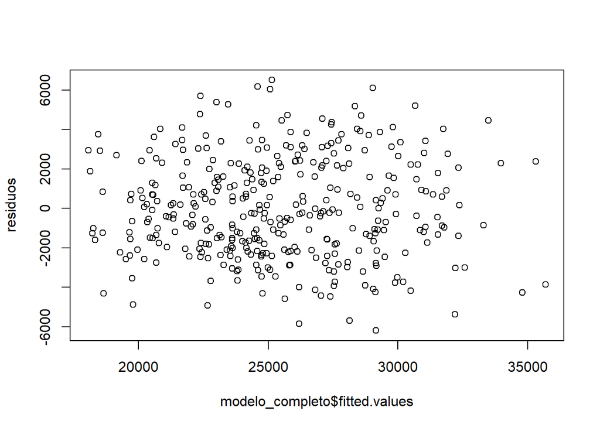

```r
plot(modelo_completo$fitted.values, residuos)
```

#### Conclusões:

Os pontos distribuem-se de forma aleatória, indicando assim homocedasticidade e homogênea, ou seja, a variabilidade dos resíduos é constante em vários níveis de predição. Se houvesse padrões, como um aumento nos resíduos à medida que os valores ajustados aumentam, isso sugeriria a presença de heterocedasticidade. Tal cenário poderia indicar que o residuo do modelo não possui variabilidade costante.

(Solução: fazer transformação em Y ou usar Mínimos Quadrados Ponderados.)

A homocedasticidade é provavelmente violada se…

1. Se os resíduos aumentam ou diminuem com os valores ajustados.
2. Se os pontos formam uma curva ao redor de zero e não estão dispostos aleatoriamente.
3. Poucos pontos no gráfico ficam muito distantes dos demais.

### Gráfico de Dispersão dos Resíduos vs. Data

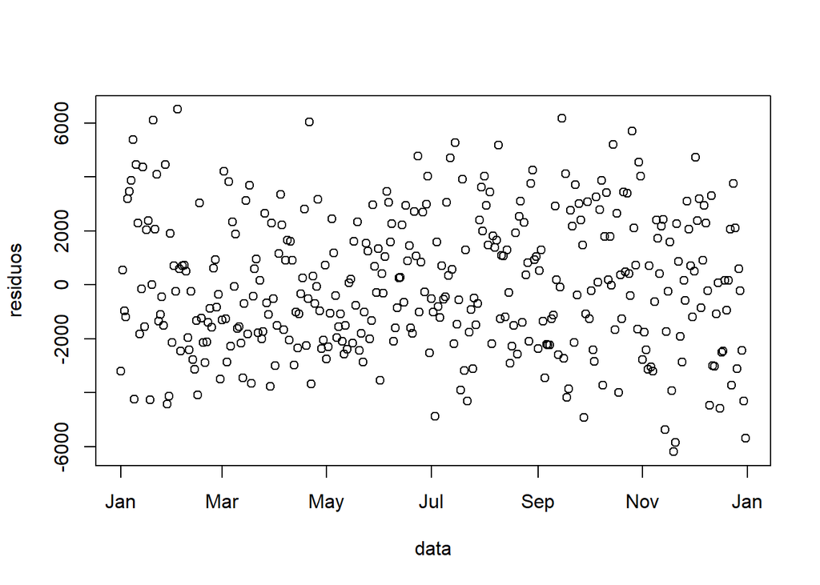

```r
plot(data, residuos)
```

#### Conclusões:

1. Os resíduos se distribuem aleatoriamente em torno de zero.
2. Não se observa nenhum padrão.
3. Isso indica que: a variância é constante; e a relação entre as variáveis é linear.

### Gráfico de Dispersão dos Resíduos vs. Temperatura_media_c

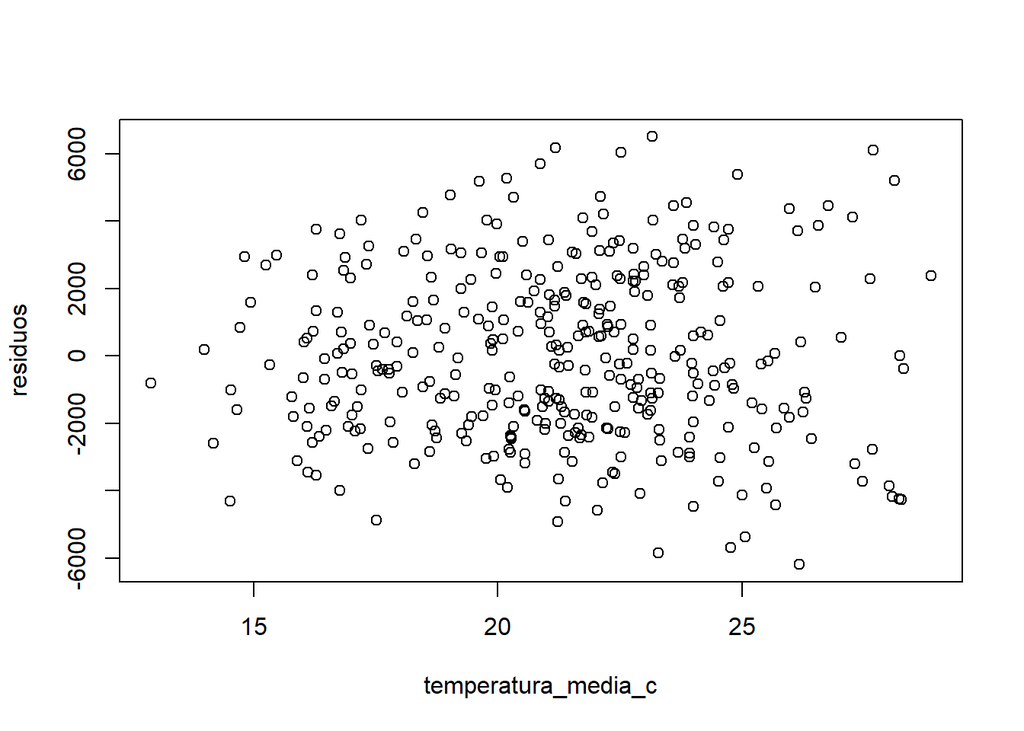

```r
plot(temperatura_media_c, residuos)
```

#### Conclusões:

Tem uma leve diferença entre os valores de 15 a 20 e depois tem uma aumento, pode repesentar uma variância não constante, mas é necessario realizar mais testes.

1. Os resíduos se distribuem aleatoriamente em torno de zero.
2. Não se observa nenhum padrão.
3. Isso indica que: a variância é constante; e a relação entre as variáveis é linear.

### Gráfico de Dispersão dos Resíduos vs. precipitacao_mm

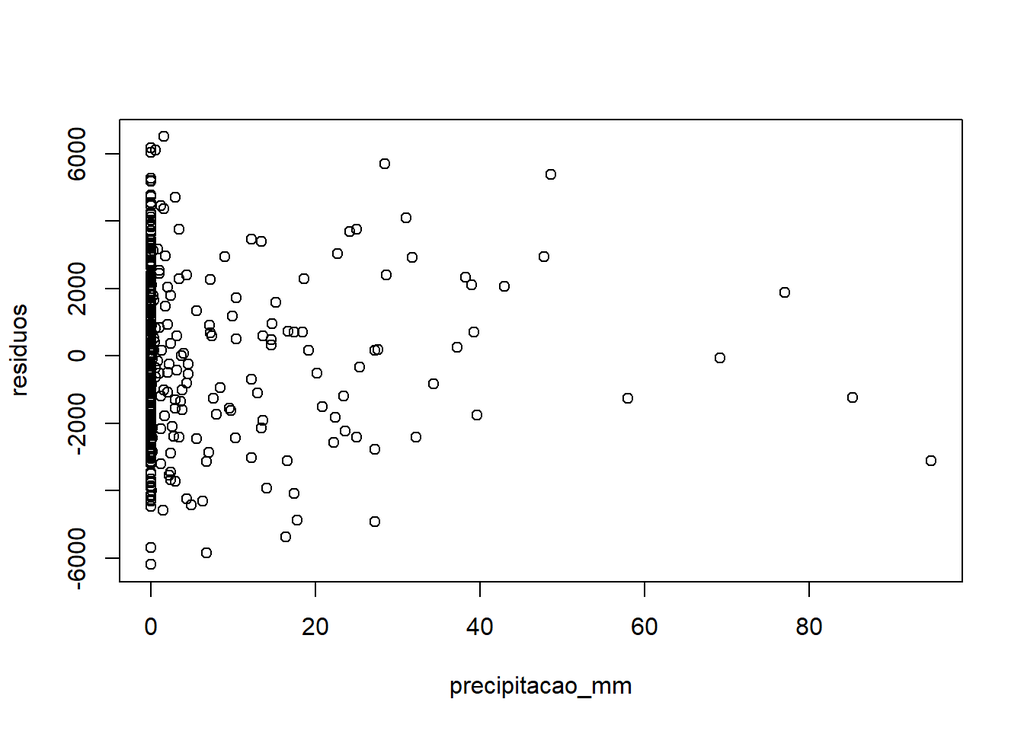

```r
plot(precipitacao_mm , residuos)
```

Conclusões:

Possui uma concentraçao no zero e tem uma leve diferença entre os valores de 0 a 20, em seguida tem uma diminuição, pode repesentar uma variância não constante, mas é necessario realizar mais testes.

1. Os resíduos se distribuem aleatoriamente em torno de zero.
2. Não se observa nenhum padrão.
3. Isso indica que: a variância é constante; e a relação entre as variáveis é linear.

### Gráfico de Dispersão dos Resíduos vs. final_de_semana

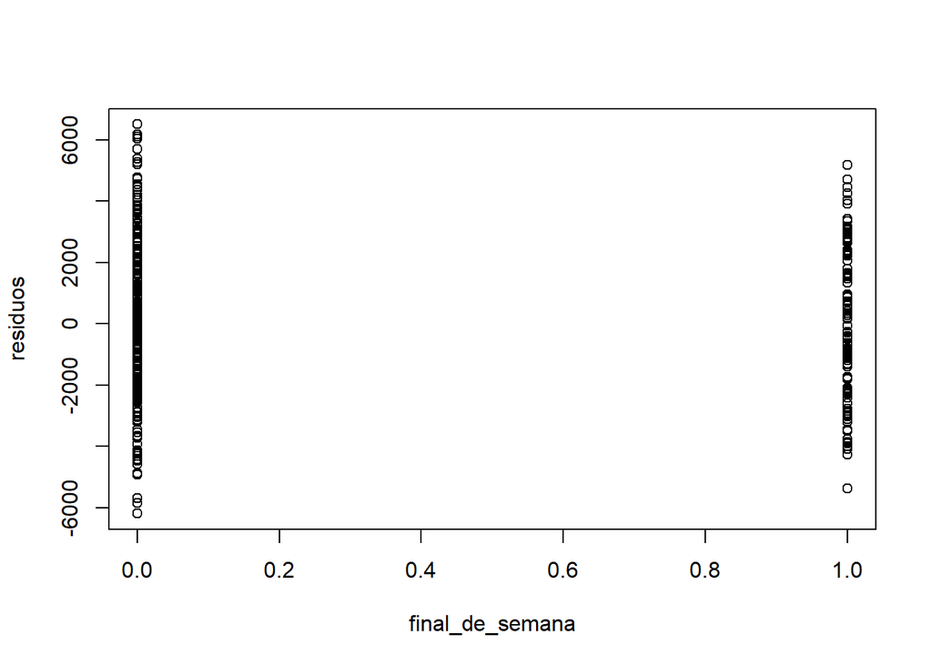

```r
plot(final_de_semana , residuos)
```

#### Conclusões:

1. Os resíduos se distribuem aleatoriamente em torno de zero.
2. Não se observa nenhum padrão.
3. Isso indica que: a variância é constante; e a relação entre as variáveis é linear.

# Gráfico de dispersão dos resíduos vs. ordem das observações

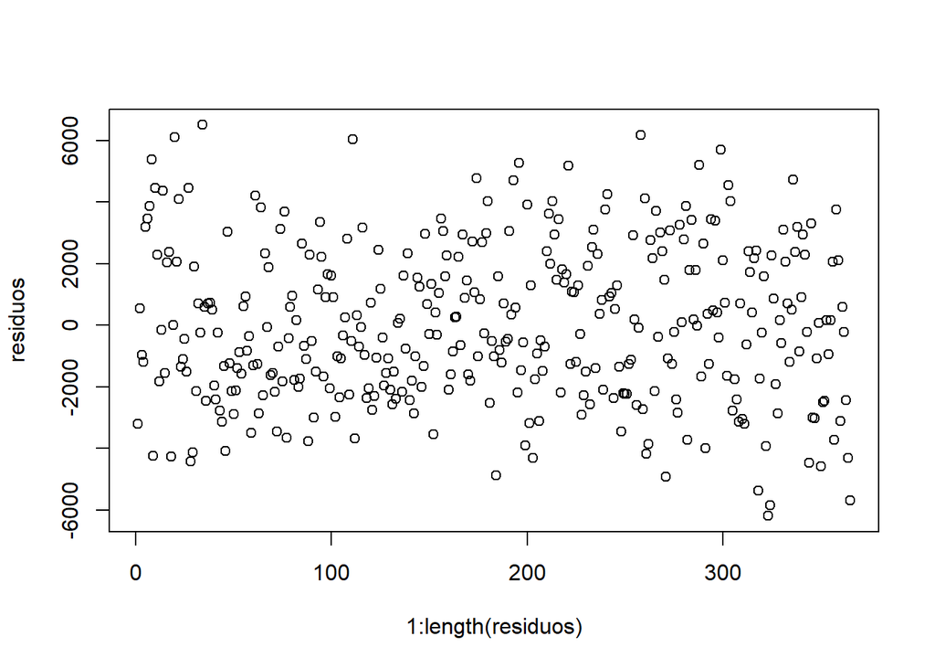

```r
plot(1:length(residuos), residuos)
```

A dispersão aleatória dos resíduos ao longo da ordem das observações mostra que o modelo está bem ajustado aos dados. Não há indicações de que o modelo esteja cometendo erros de maneira sistemática ou previsível.

### Gráfico QQ-plots

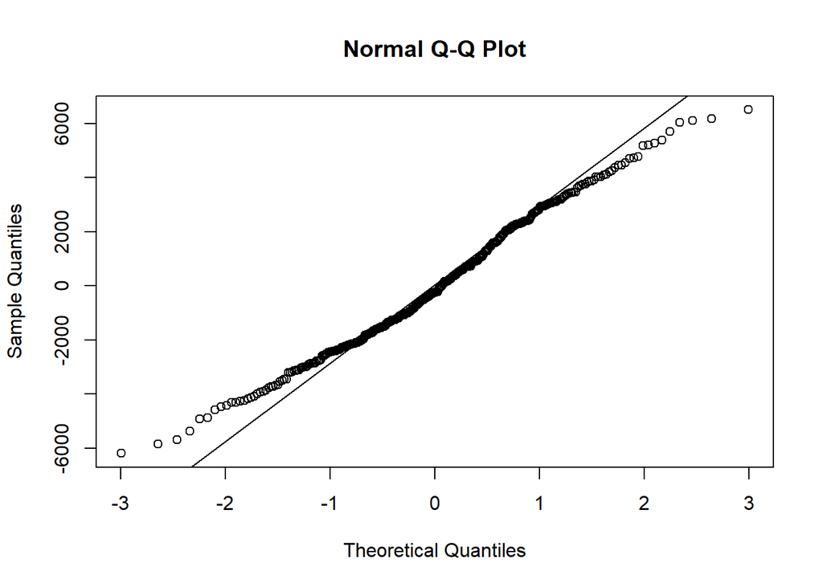

```r
qqnorm(residuos)
qqline(residuos)
```

#### Conclusões:

Podemos ver que os resíduos tendem a se desviar um pouco da linha perto das caudas, o que pode indicar que eles não estão normalmente distribuídos.

### Teste de normalidade dos resíduos (Shapiro-Wilk)

```r
shapiro.test(residuos)
```

```
##
##  Shapiro-Wilk normality test
##
## data:  residuos
## W = 0.98964, p-value = 0.01106
```

#### Hipótese:

$$\left\{ \begin{array}{rc}
H0: Os \ erros \ têm \ distribuição \ normal \\
H1: Os \ erros \ não \ têm \ distribuição \ normal \\
\end{array}\right.$$

##### Conclusões:

Como resultado, o teste retornará a estatística W, que terá um valor de significância associada, o valor-p. Para dizer que uma distribuição é normal, o valor p precisa ser maior do que 0,05. Logo rejeitar a hipótese nula concluimos que os erros não tem distribuição normal.

### Teste de autocorrelação dos resíduos (Durbin-Watson)

```r
durbinWatsonTest(modelo_completo)
```

```
##  lag Autocorrelation D-W Statistic p-value
##    1      0.03100611      1.919447   0.348
##  Alternative hypothesis: rho != 0
```

#### Hipótese:

$$\left\{ \begin{array}{rc}
H0: 𝜌 = 0 \\
H1: 𝜌 \neq 0 \\
\end{array}\right.$$

##### Conclusões:

Ele faz uma estatística que testa se eles são independentes. Aí, o p-valor que a gente compara é com 0.05, nesse caso, o p-valor não foi menor do que 0.05. Logo, a gente não tem evidência suficiente para rejeitar a hipótese nula. Se eu não consigo rejeitar é porque eu não tenho evidências para dizer que elas não são independentes. Então, eu aceito que são independentes e não há autocorrelação significativa.

### Conclusões Geral:

É possível que seja necessário transformar a variável de resposta para abordar a falta de normalidade nos resíduos, facilitando assim a aprovação no teste de Shapiro-Wilk. No entanto, em relação à aplicação de mínimos quadrados ponderados, a evidência de falta de homocedasticidade nos resíduos não é conclusiva, necessitando de mais testes.

## Questão G

Realize a análise de diagnóstico do modelo, apresentando os gráficos de todas as medidas estudadas (DFFITS, DFBETAS, Distância de Cook, leverage, resíduos estudentizados). Interprete cada uma usando o gráfico e CALCULE o ponto de corte visto no livro para comparar.

### DFFIT

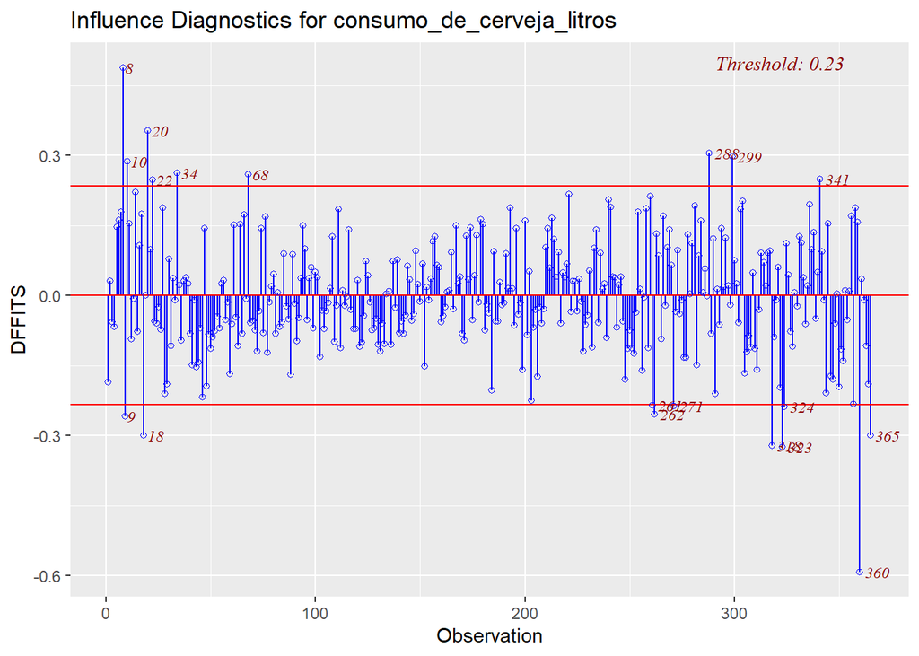

```r
ols_plot_dffits(modelo_completo)
```

#### Conclusões:

DFFIT - diferença nos ajustes, é usado para identificar pontos de dados influentes. Ele quantifica o número de desvios padrão que o valor ajustado muda quando o i-ésimo ponto de dados é omitido.

Pontos ultrapassao a linha podem ser considerados pontos influentes.

### DFBETAS

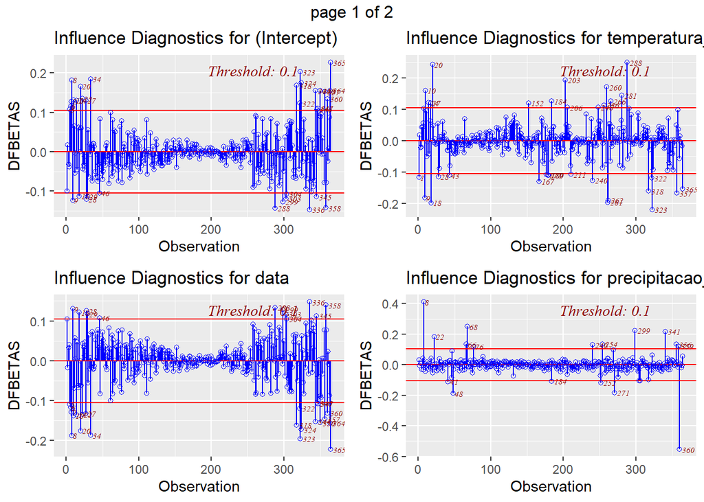

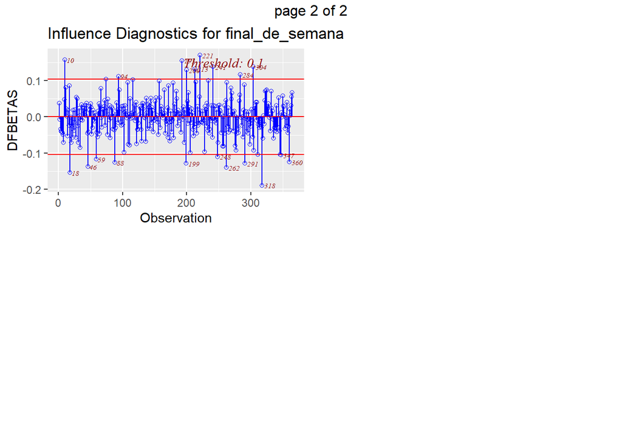

```r
ols_plot_dfbetas(modelo_completo)
```

### Cook’s distance

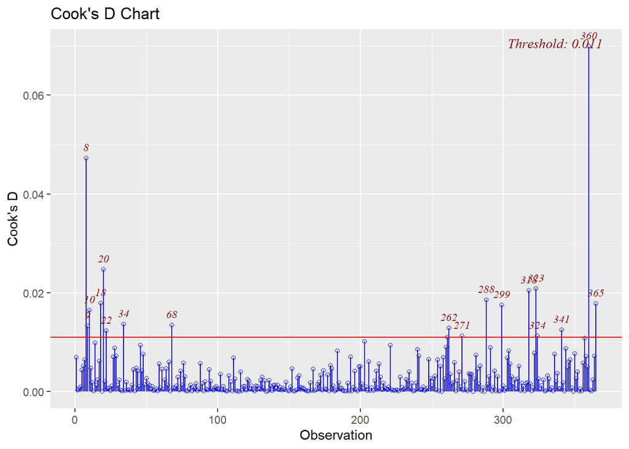

```r
ols_plot_cooksd_chart(modelo_completo)
```

#### Conclusões:

Gráfico de barras da distância de Cook para detectar observações que influenciam fortemente os valores ajustados do modelo. A distância de Cook foi introduzida pelo estatístico americano R Dennis Cook em 1977. É usada para identificar pontos de dados influentes. Depende tanto do resíduo quanto da alavancagem, ou seja, leva em consideração tanto o valor x quanto o valor y da observação. Passos para calcular a distância de Cook:

- exclua as observações uma de cada vez.
- reajuste o modelo de regressão no restante (n−1) observações
- examine quanto todos os valores ajustados mudam quando a i-ésima observação é excluída.

Um ponto de dados com distância Cook grande indica que o ponto de dados influencia fortemente os valores ajustados.

### Studentized Residuals vs Leverage Plot

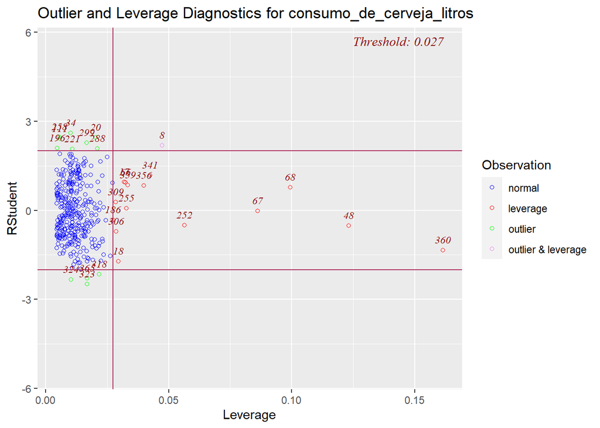

```r
ols_plot_resid_lev(modelo_completo)
```

#### Conclusões:

Gráfico para detecção de outliers e/ou observações com alta influencia

### Resíduos Studentizados

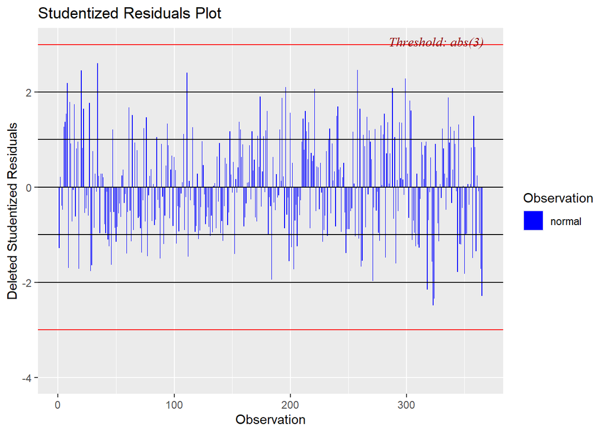

```r
ols_plot_resid_stud(modelo_completo)
```

#### Conclusões:

Gráfico para detecção de outliers. Resíduos excluídos estudantis (ou resíduos estudantis externamente) são os resíduos excluídos divididos por seu desvio padrão estimado. Os resíduos estudantis serão mais eficazes para detectar observações Y periféricas do que os resíduos padronizados. Se uma observação tiver um resíduo estudantil externamente maior que 3 (em valor absoluto), podemos chamá-la de outlier.

# Regressão Logística

## Questão A

Escreva a equação do modelo ajustado, capaz de descrever o relacionamento existente entre a ocorrência de sinistro e as variáveis em estudo.

```r
sinistro <- read.delim("dados/dadosSinistro.txt")
```

```r
modelo=glm(Sinistro~Idade+ECivil+Sexo,data = sinistro,
           family=binomial(link="logit"))
summary(modelo)
```

```
##
## Call:
## glm(formula = Sinistro ~ Idade + ECivil + Sexo, family = binomial(link = "logit"),
##     data = sinistro)
##
## Deviance Residuals:
##     Min       1Q   Median       3Q      Max
## -1.3375  -0.3070  -0.1441   0.2496   2.0702
##
## Coefficients:
##             Estimate Std. Error z value Pr(>|z|)
## (Intercept)  3.78103    1.94470   1.944  0.05186 .
## Idade       -0.18957    0.07228  -2.623  0.00872 **
## ECivil      -3.62511    1.65160  -2.195  0.02817 *
## Sexo         3.70268    1.67313   2.213  0.02690 *
## ---
## Signif. codes:  0 '***' 0.001 '**' 0.01 '*' 0.05 '.' 0.1 ' ' 1
##
## (Dispersion parameter for binomial family taken to be 1)
##
##     Null deviance: 42.541  on 35  degrees of freedom
## Residual deviance: 20.990  on 32  degrees of freedom
## AIC: 28.99
##
## Number of Fisher Scoring iterations: 6
```

## Questão B

Explicar o significado de cada componente do modelo;

#### Conclusões:

beta 1 = - 0.19 o log da razão de chances diminui em 0.19 quando seaumenta uma unidade na variável idade e mantém as demais variáveisconstantes. A estimativa negativa de Beta1 indica que aumentando-se avariável idade, diminui-se a chance de sucesso (sinistro) Beta2 = -3,62: diminuição no log da razão de chances quando se muda oestado civil de casado para solteiro. Beta3 = 3,70: aumento no log da razão de chances quando se muda dosexo masculino para o feminino. A estimativa positiva de Beta3 indica queo sexo codificado como 1, tem maior chance de sucesso (sinistro) quandocomparado com o estado codificado como zero.

O AIC estima a quantidade relativa de informação perdida por um determinado modelo: quanto menos informações um modelo perde, maior a qualidade desse modelo e menor a pontuação AIC.

## Questão C

Teste a significância do modelo por meio do Teste de razão de verossimilhança, apresentando as hipóteses e conclusão. Teste a significância dos parâmetros do modelo e apresente as conclusões, em termos das variáveis. Use 1% de significância.

```r
paste0('TRV = ',modelo[["null.deviance"]]-modelo[["deviance"]],' e ',
       qchisq(0.99,3), ' há 95% e 3p')
```

```
## [1] "TRV = 21.5506493356017 e 11.3448667301444 há 95% e 3p"
```

#### Conclusões:

Dado que o TRV é maior que qui quadrado há 99% e com 3 parametros o modelo como um todo é significativo, rejeitamos h0.

Lembrando:

Considere dois modelos um “completo” (Mc ) e o outro “restrito” (Mr) quanto à quantidade de parâmetros.Então a estatística de teste é:

TRV = 2 [log(L(Mc )) − log(L(Mr))].

$$\left\{ \begin{array}{rc}
H0: Igualdade \ entre \ os \ dois \ modelos \\
H1: Difernça \ entre \ os \ dois \ modelos \\
\end{array}\right.$$

Sob a hipóotese de igualdade entre os dois modelos, TRV tem distribuição aproximada de Qui-Quadrado com graus de liberdade igual ao número de restrições (diferença entre as quantidades de parâmetros).

## Questão D

Interprete as razões de chance e os intervalos de confiança obtidas para todos os parâmetros;

### Intervalos de confiança

```r
ICbeta=confint.default(modelo,level=0.95)
ICbeta
```

```
##                   2.5 %      97.5 %
## (Intercept) -0.03051846  7.59258396
## Idade       -0.33123689 -0.04790661
## ECivil      -6.86218543 -0.38803500
## Sexo         0.42339383  6.98195617
```

### odds ratio – OR (chance)

```r
OR=exp(modelo$coefficients)
OR
```

```
## (Intercept)       Idade      ECivil        Sexo
## 43.86131610  0.82731335  0.02664616 40.55564586
```

#### Conclusões:

A chance de haver sinistro(1) é de cerca de 0.83 vezes menos para cada ano de acrescentado na idade, ou seja, as chances de a haver sinistro é de 17% menor a cada ano de acrescentado na idade; A chance de haver sinistro(1) é de cerca de 0.027 vezes menos quando estado civil igual a Solteiro(1), ou seja, as chances de a haver sinistro é de 97.3% menor se for Solteiro; A chance de haver sinistro(1) é de cerca de 40.55 vezes maior se o sexo for Feminino(1).

Odds 1 = 0.83 representa a diminuição na chance de sinistro quando seaumenta uma unidade na idade. A chance de sinistro diminui cerca de17 % (1-0,83) quando se aumenta um ano na idade e mantém as demaisvariáveis constantes. Odds2 = 0.027 representa a diminuição na chance de sinistro de umindividuo solteiro, em comparação com um casado. Portanto, o indivíduosolteiro tem cerca de 98% (1-0,027) menos chances de sinistro do que umcasado Odds3 = 40,55 representa o aumento na chance de sinistro quando oindivíduo é feminino. Assim, o feminino tem 40 vezes mais chance desinistro do que o masculino

### Intervalos de confiança para as razões de chance

```r
ICOR=exp(ICbeta);
round((cbind(OR, ICOR)),3)
```

```
##                 OR 2.5 %   97.5 %
## (Intercept) 43.861 0.970 1983.432
## Idade        0.827 0.718    0.953
## ECivil       0.027 0.001    0.678
## Sexo        40.556 1.527 1077.023
```

## Questão E

Estime a probabilidade de sinistro associada a um cliente do sexo masculino, casado com 25 anos de idade

```r
p_sexo = 0
p_ec = 0
p_idade = 25

razaopiest = exp(modelo[["coefficients"]]['(Intercept)'][[1]] +
                 (modelo[["coefficients"]]['Idade'][[1]] * p_idade) +
                 (modelo[["coefficients"]]['ECivil'][[1]] * p_ec) +
                 (modelo[["coefficients"]]['Sexo'][[1]] * p_sexo)
                 )

paste0('Estimação da probabilidade de sinistro = ',
       (razaopiest /(1 + razaopiest)))
```

```
## [1] "Estimação da probabilidade de sinistro = 0.277226495853509"
```

## Questão F

Para o mesmo cliente citado no item anterior, qual a probabilidade de sinistro se ele for solteiro?

```r
p_sexo = 0
p_ec = 1
p_idade = 25

razaopiest = exp(modelo[["coefficients"]]['(Intercept)'][[1]] +
                 (modelo[["coefficients"]]['Idade'][[1]] * p_idade) +
                 (modelo[["coefficients"]]['ECivil'][[1]] * p_ec) +
                 (modelo[["coefficients"]]['Sexo'][[1]] * p_sexo)
                 )

paste0('Estimação da probabilidade de sinistro = ',
       (razaopiest /(1 + razaopiest)))
```

```
## [1] "Estimação da probabilidade de sinistro = 0.010116983059195"
```

## Questão G

Compare os resultados obtidos nos dois itens anteriores e reflita sobre as estratégias que poderiam ser adotadas pela companhia para atrair novos clientes.

#### Conclusões:

Com base na estimação anterioir e para os parametros colocados a prova podemos dizer que para a companhia seria benefico focar em atrai solteiros dados que a chance de haver sinistro diminui muito.

## Questão H

Considere um nível de significância de 1% para excluir variáveis do modelo e comparar o modelo reduzido com o modelo completo, usando o teste de razão de verossimilhança. Decida qual o melhor modelo, com base nesse teste.

```r
modelo=glm(Sinistro~Idade+ECivil+Sexo,data = sinistro,
           family=binomial(link="logit"))
summary(modelo)
```

```
##
## Call:
## glm(formula = Sinistro ~ Idade + ECivil + Sexo, family = binomial(link = "logit"),
##     data = sinistro)
##
## Deviance Residuals:
##     Min       1Q   Median       3Q      Max
## -1.3375  -0.3070  -0.1441   0.2496   2.0702
##
## Coefficients:
##             Estimate Std. Error z value Pr(>|z|)
## (Intercept)  3.78103    1.94470   1.944  0.05186 .
## Idade       -0.18957    0.07228  -2.623  0.00872 **
## ECivil      -3.62511    1.65160  -2.195  0.02817 *
## Sexo         3.70268    1.67313   2.213  0.02690 *
## ---
## Signif. codes:  0 '***' 0.001 '**' 0.01 '*' 0.05 '.' 0.1 ' ' 1
##
## (Dispersion parameter for binomial family taken to be 1)
##
##     Null deviance: 42.541  on 35  degrees of freedom
## Residual deviance: 20.990  on 32  degrees of freedom
## AIC: 28.99
##
## Number of Fisher Scoring iterations: 6
```

```r
deviance_completo = modelo[["deviance"]]

modelo=glm(Sinistro~Idade,data = sinistro,
           family=binomial(link="logit"))
summary(modelo)
```

```
##
## Call:
## glm(formula = Sinistro ~ Idade, family = binomial(link = "logit"),
##     data = sinistro)
##
## Deviance Residuals:
##     Min       1Q   Median       3Q      Max
## -1.2066  -0.9398  -0.4521   1.2628   1.6573
##
## Coefficients:
##             Estimate Std. Error z value Pr(>|z|)
## (Intercept)  1.54670    1.26218   1.225   0.2204
## Idade       -0.08212    0.04364  -1.882   0.0599 .
## ---
## Signif. codes:  0 '***' 0.001 '**' 0.01 '*' 0.05 '.' 0.1 ' ' 1
##
## (Dispersion parameter for binomial family taken to be 1)
##
##     Null deviance: 42.541  on 35  degrees of freedom
## Residual deviance: 37.033  on 34  degrees of freedom
## AIC: 41.033
##
## Number of Fisher Scoring iterations: 5
```

```r
deviance_idade = modelo[["deviance"]]

paste0('TRV = ',deviance_idade-deviance_completo,' e ',
       qchisq(0.99,2), ' há 99% e 4-2=2p')
```

```
## [1] "TRV = 16.0425922111344 e 9.21034037197618 há 99% e 4-2=2p"
```

#### Conclusões:

Dado que o TRV é maior que qui quadrado há 99% e com 2 parametros, temos que o modelo com ECivil+Sexo(completo) como um todo é significativo. Rejeitamos h0.

Lembrando:

$$\left\{ \begin{array}{lc}
H0: Modelo \ só \ com \ 1 \ variável (X1) \ é \ melhor \ que \ o \
modelo \ com \ 3 \\
\ \ \ \ \ \ \ \ \ variáveis(ou \ seja, \ a \ contribuição \ de \ X2 \ e
\ X3 \ não \ é \ significativa) \\
H1: Modelo \ completo \ é \ melhor \ que \ o \ reduzido \\
\end{array}\right.$$

Sob a hipóotese de igualdade entre os dois modelos, TRV tem distribuição aproximada de Qui-Quadrado com graus de liberdade igual ao número de restrições (diferença entre as quantidades de parâmetros).

Quanto mais elevada a diferença entre os dois valores, maioro potencial dos coeficientes para estimar probabilidadesassociadas a ocorrência de determinado evento.

Essa diferença serve para testar a hipótese de que todos oscoeficientes do modelo logístico são iguais a zero, tal como severifica na distribuição F.